# Eat, Pray, R

A journey through the merits, joys, and beauties of command line programming

Robert Schlegel

November 26th, 2018

## Why use R?

- Its free!
- Its not Microsoft
- One program
- Human readable
- Community support
- Statistical analyses
- Graphing capabilities
- Reproducible research

## Reproducible research

Why must our research be reproducible?

[figure not shown]

## Reproducible research

How does excel fail in this regard?

[figure not shown]

## Reproducible research

Why do people still use it anyway?

[figure not shown]

## Benefits of R

There are many ways in which R may make our lives easier:

- Streamline work flow
- Simplify complex tasks
- Reuse old scripts
- Use other peoples scripts
- Create beautiful figures
- Manage large data files
- What else?

## Streamline workflow

Load -> Prepare -> Process -> Graph

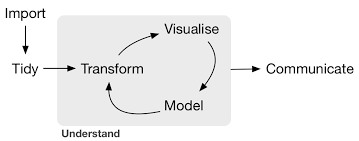

## Simplify complex tasks

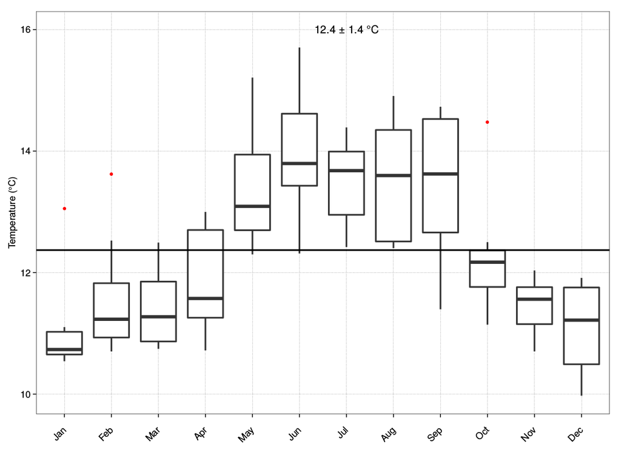

```r
ggplot(site1, aes(x = month, y = temp)) +
  geom_boxplot(outlier.colour = "red", outlier.size = 2.0, size = 1.0) +
  geom_hline(data = annual1, linetype = "solid", size = 1.0, aes(yintercept = mean)) +
  geom_text(data = annual1, size = 5.0,
            aes(x, y, label = paste("", signif(mean, digits = 3), " ± ",
                              signif(sd, digits = 2), " °C", sep = ""))) +
  ylab(expression(paste("Temperature (",degree,"C)")))
```

## Simplify complex tasks

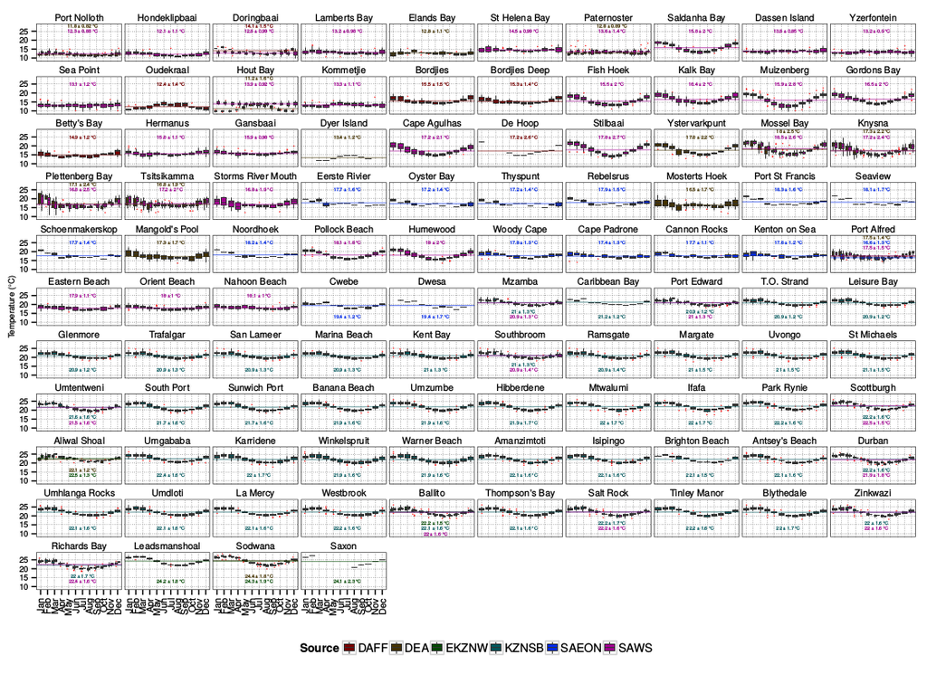

[figure not shown]

[figure not shown]

[figure not shown]

[figure not shown]

```r
ggplot(insituMonthlyMultisite_v3.3, aes(x = month, y = temp, fill = src)) +
  geom_boxplot(outlier.colour = "red", outlier.size = 0.5, size = 0.1) +
  geom_hline(data = annual, linetype = "solid", size = 0.4,
             aes(yintercept = mean, colour = src, alpha = 0.6)) +
  geom_text(data = annual, size = 1.5,
            aes(x, y, label = paste("", signif(mean, digits = 3), " ± ",
                                    signif(sd, digits = 2), " °C", sep = ""),
                group = src, colour = src)) +
  ylab(expression(paste("Temperature (",degree,"C)"))) +
  facet_wrap(~ site, ncol = 10)
```

## Make data more manageable

Our datasets are becoming larger and larger.

[figure not shown]

- Who here has used a dataset with more than 100 rows of data?
- More than 1,000?
- More than 1,000,000?

## Big Data

We hear this term more and more… but what does it mean?

[figure not shown]

## Big Data

> Noun: An accumulation of data that is too large and complex for processing by traditional database management tools.

[figure not shown]

## Science Careers

But what does all of this have to do with you?

[figure not shown]

The standards for good science are rising.

## Science Careers

Planning on leaving Academia after your undergraduate degree?

Knowledge of R or other command line programs is a highly salable skill.

[figure not shown]

Excel is no longer good enough.

## Real world example

South African Coastal Temperature Network (SACTN):

## SACTN

R is used to:

- Manage data
- Perform analyses
- Create data products
- [Create web app for data access](https://robert-schlegel.shinyapps.io/SACTN/)
- Write reports
- Prepare presentations
- Compile research articles

[figure not shown]